# Berry Fire point selection

Kristin Braziunas

## Purpose

The purpose of this script is to randomly select points for analysis in Q1 (young v. old forest) and Q2 (moderate v. high spread days). At the end of this script, I also calculate summary information about the Berry Fire (high, low spread days; fire weather).

```r
# load libraries
library(sp) # version 1.3-1
library(rgdal) # version 1.4-4
library(raster) # version 3.0-2
library(dplyr) # version 0.8.3
library(sf) # version 0.7-7
library(fasterize) # version 1.0.0
library(rgeos) # version 0.5-1
```

## 1. Load data

This chunk loads the Berry Fire RdNBR raster, Berry Fire perimeter, and 30m DEM for Grand Teton National Park (GRTE).

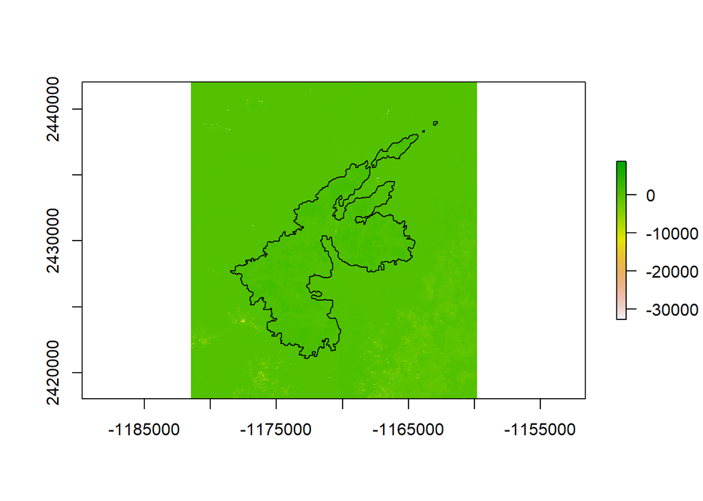

```r
# mtbs final fire perimeter
perim.in = readOGR("data/MTBS/Berry_Fire/wy4402111078620160725_20160719_20170722_burn_bndy.shp",
                  layer="wy4402111078620160725_20160719_20170722_burn_bndy")


# fire severity raster
sev.in = raster("data/MTBS/Berry_Fire/wy4402111078620160725_20160719_20170722_rdnbr.tif")

# dem derived from lidar
dem.in = raster("processed_data/GRTE_rasters/grte_30m_dem.tif")

plot(sev.in)
plot(perim.in, add=TRUE)
```

## 2. Mask Berry Fire severity raster

I masked Berry Fire burn severity to only includes pixels within the fire perimeter that were likely burned (RdNBR > 0) and excluding anomalously high values (RdNBR < 2000). Then, I further masked this raster to exclude areas where fuels were not mapped: forests outside of GRTE and John D. Rockefeller Jr. Memorial Parkway (JODR), vegetation that was not either mature or regenerating post-fire conifer forest.

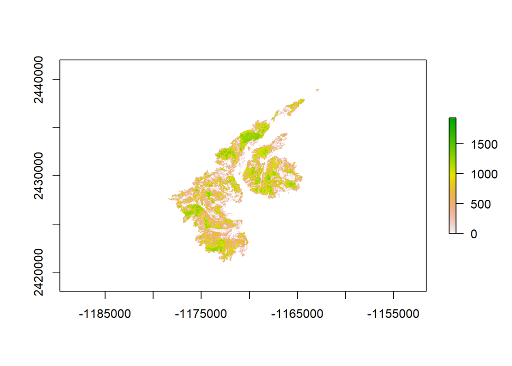

```r
# mask with berry fire perimeter
identicalCRS(sev.in,perim.in)  # true

sev.p = mask(sev.in, perim.in)

# take out negative and anomalous high values
sev.p[values(sev.p)<0] = NA  # using 0 to exclude anything
# with increased greenness or likely unburned
sev.p[values(sev.p)>2000] = NA  # 2000 is cut-off from harvey et al. 2016 Ecology

# hist(values(sev.p))

plot(sev.p)
```

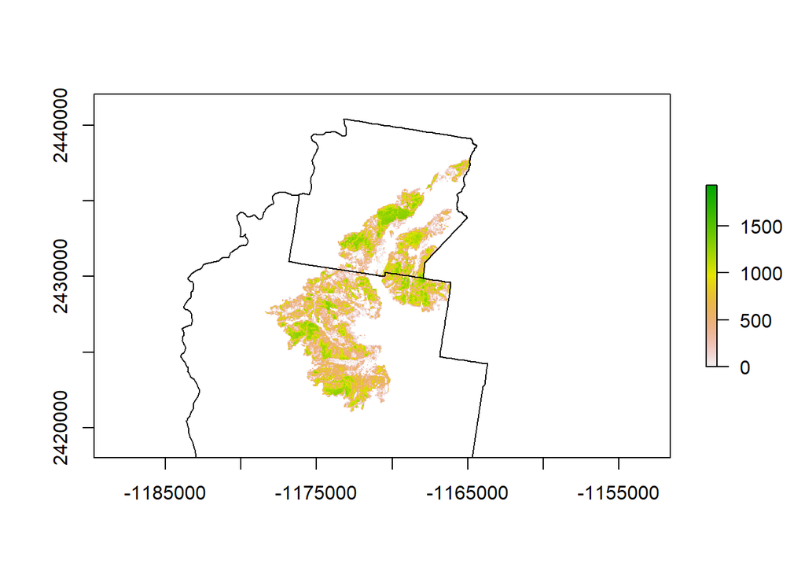

```r
# use nps perimeters to exclude areas outside of GRTE and JODR
# because fuels only mapped in GRTE and JODR

bound = readOGR("data/NPSAdminBoundaries/NPSAdminBoundaries.shp")
identicalCRS(sev.p, bound)

grte = bound[bound@data$UNIT_CODE %in% c("GRTE","JODR"),]
# plot(grte)

grte.aea = spTransform(grte, CRSobj = crs(sev.p))

# plot(sev.p)
# plot(grte.aea, add=TRUE)

sev.grte = mask(sev.p, grte.aea)

plot(sev.grte)
plot(grte.aea, add=TRUE)
```

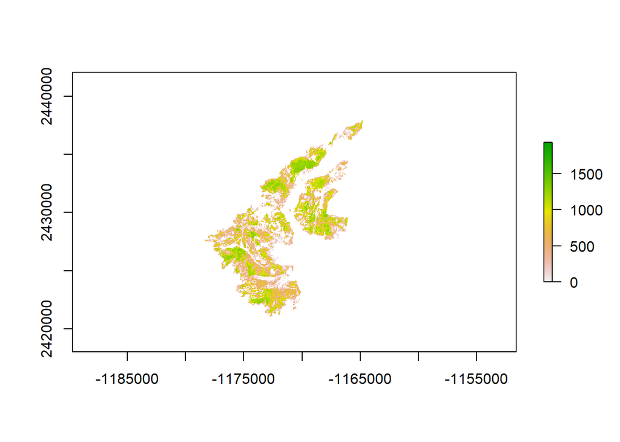

```r
# then use veg map to mask to only conifer forest, including what might have been labeled recently burned in 2005

veg = readOGR("data/GRTE_Veg/GRTE_Veg.shp")

con = veg[veg@data$ECOLOGY %in% c("Coniferous Woodland") | veg@data$VEG_NAME == "Recently Burned Sparse Vegetation",]

con.aea = spTransform(con, CRSobj=crs(sev.grte))

sev.con = mask(sev.grte, con.aea)

plot(sev.con)
```

## 3. Differentiate moderate versus extreme fire weather days

I used daily fire progression maps to differentiate areas that burned under moderate versus extreme fire weather. Extreme fire weather days included 3 periods (covering 4 days) of extensive, rapid fire spread.

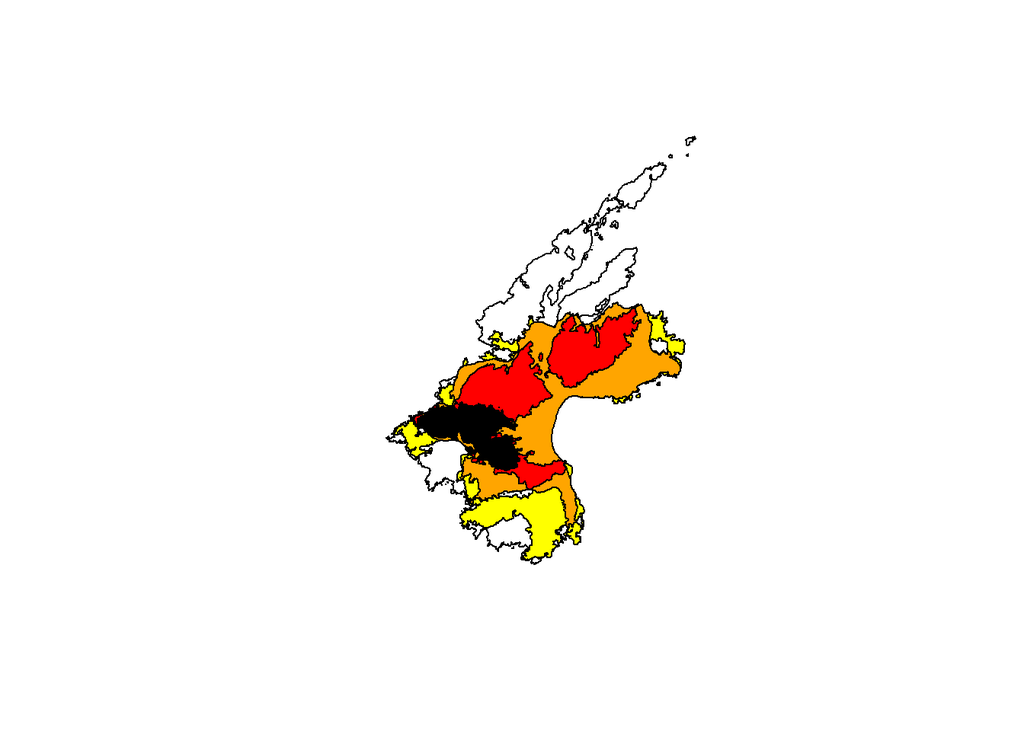

```r
### read in fire perimeters for high spread days
# 822 and 823-824
pre822 = readOGR("data/GeoMAC/2016_fire_data/Wyoming/Berry/wy_berry_20160822_0221_dd83.shp")
post822 = readOGR("data/GeoMAC/2016_fire_data/Wyoming/Berry/wy_berry_20160822_2009_dd83.shp")
post824 = readOGR("data/GeoMAC/2016_fire_data/Wyoming/Berry/wy_berry_20160824_2112_dd83.shp")

# 911
pre911 = readOGR("data/GeoMAC/2016_fire_data/Wyoming/Berry/wy_berry_20160910_2256_dd83.shp")
post911 = readOGR("data/GeoMAC/2016_fire_data/Wyoming/Berry/wy_berry_20160912_0058_dd83.shp")

plot(post911)
plot(pre911,add=TRUE,col="yellow")
plot(post824, add=TRUE,col="orange")
plot(post822,add=TRUE,col="red")
plot(pre822,add=TRUE, col="black")
```

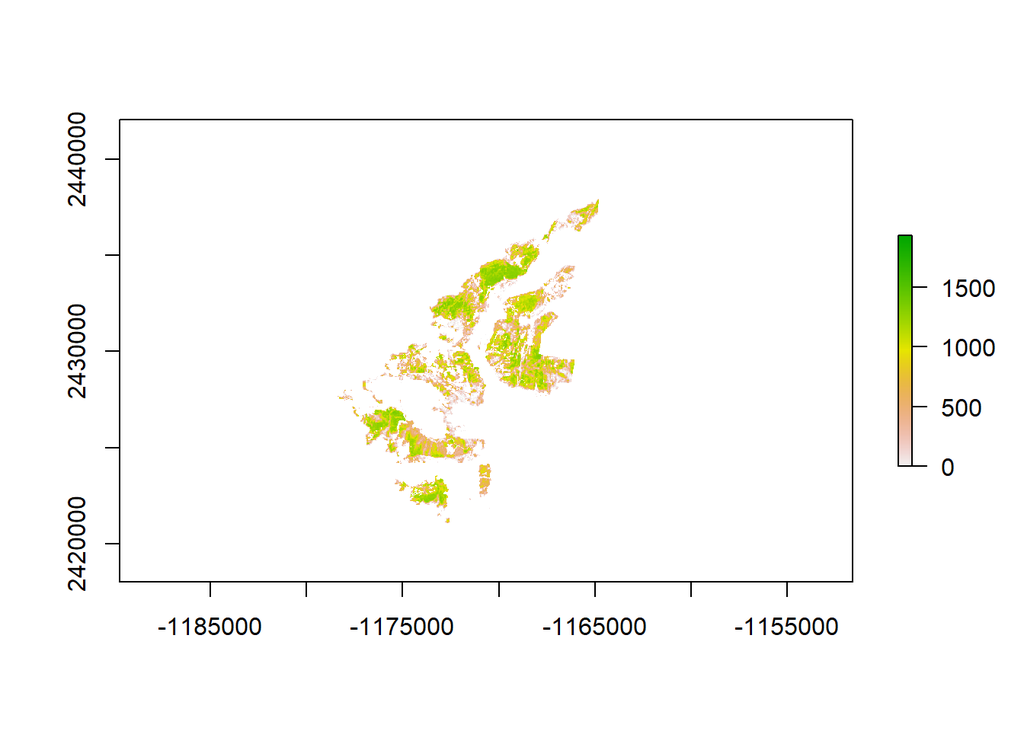

```r
identicalCRS(post911,sev.con)

# transform to same crs as RdNBR rasters
post911.aea = spTransform(post911,CRSobj = crs(sev.con))
pre911.aea = spTransform(pre911,CRSobj = crs(sev.con))
post824.aea = spTransform(post824,CRSobj = crs(sev.con))
post822.aea = spTransform(post822,CRSobj = crs(sev.con))
pre822.aea = spTransform(pre822,CRSobj = crs(sev.con))

# start with 911
pm911 = mask(sev.con, post911.aea)
growth911 = mask(pm911, pre911.aea, inverse=TRUE)

# plot(growth911)

# then 823-824
pm824 = mask(sev.con,post824.aea)
growth824 = mask(pm824, post822.aea, inverse=TRUE)

# plot(growth824)

# then 822
pm822 = mask(sev.con, post822.aea)
growth822 = mask(pm822, pre822.aea, inverse=TRUE)

# plot(growth822)

# combined growth on these high spread dates
growthHi = merge(growth911,growth824, growth822)
plot(growthHi)
```

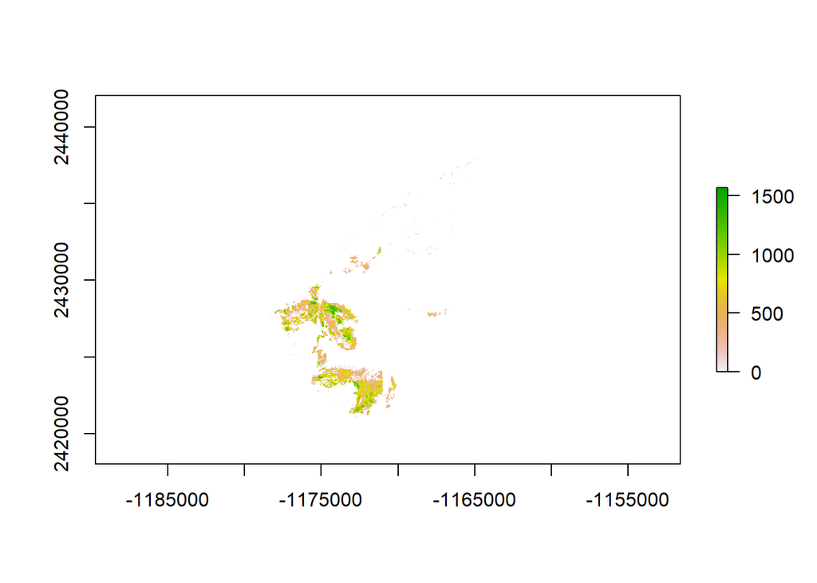

```r
# growth on other than these 3 days
# plot(sev.con)
growthMod = mask(sev.con, growthHi, inverse=TRUE)
plot(growthMod)
```

## 4. Differentiate young versus mature forest

Within areas burned in 2016, for Q1 I identified reburns of young, ~30-year-old forest that had previously burned in 1987 or 1988. Young forest included only areas that had burned as stand-replacing fire (RdNBR > 675) in the first fire and then reburned at any severity in 2016. I identified mature forest as areas that burned in the Berry Fire and were outside of fire perimeters from 1987, 1988, and 2000.

For Q1 comparison of young and mature forest fuels and burn severity, I minimized variation due solely to differences in fire weather by restricting comparison to areas that burned during extreme weather days as delineated in the previous chunk.

For Q2, I also identified areas that burned in 2000 at moderate or high severity to determine how many pixels in our random sample were young forest.

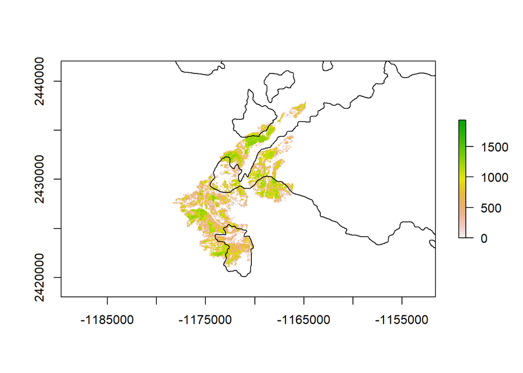

```r
### read in young fire perimeters
# glade fire perimeter
glade = readOGR("data/MTBS/Glade/wy4409911072120000815/wy4409911072120000815_20000723_20010726_burn_bndy.shp")

# huck fire perimeter - this includes 1987 dave adams hill fire perimeter
lake = readOGR("data/MTBS/Lake_Creek/wy4415711051919880711/wy4415711051919880711_19860818_19890802_burn_bndy.shp")

# wilcox fire perimeter
wilcox = readOGR("data/MTBS/Wilcox/wy4397811071720000815_20000723_20010726_burn_bndy.shp")

# plot(glade)
# plot(lake)
# plot(wilcox)

# change crs
glade.aea = spTransform(glade, CRSobj=crs(sev.con))
lake.aea = spTransform(lake, CRSobj=crs(sev.con))
wilcox.aea = spTransform(wilcox, CRSobj = crs(sev.con))

plot(sev.con)
plot(glade.aea, add=TRUE)
plot(lake.aea, add=TRUE)
plot(wilcox.aea,add=TRUE)
```

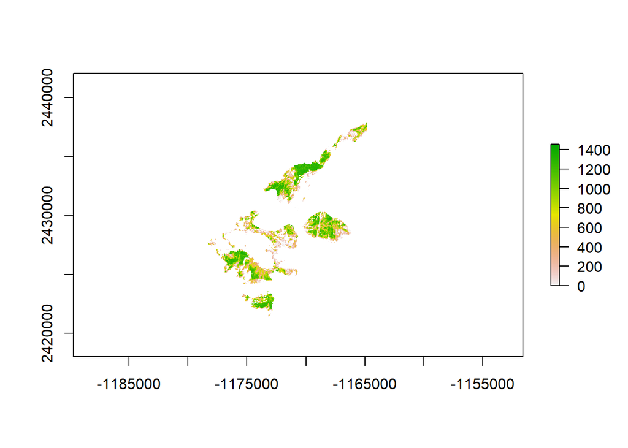

```r
# sev old is everything outside of glade, huck (+adams hill), wilcox perimeters
sev.old = mask(mask(mask(sev.con, glade.aea, inverse=TRUE), lake.aea,inverse=TRUE),wilcox.aea,inverse=TRUE)

# only high fire spread days, to keep fire weather similar
sevHi.old = mask(sev.old, growthHi)
plot(sevHi.old)
```

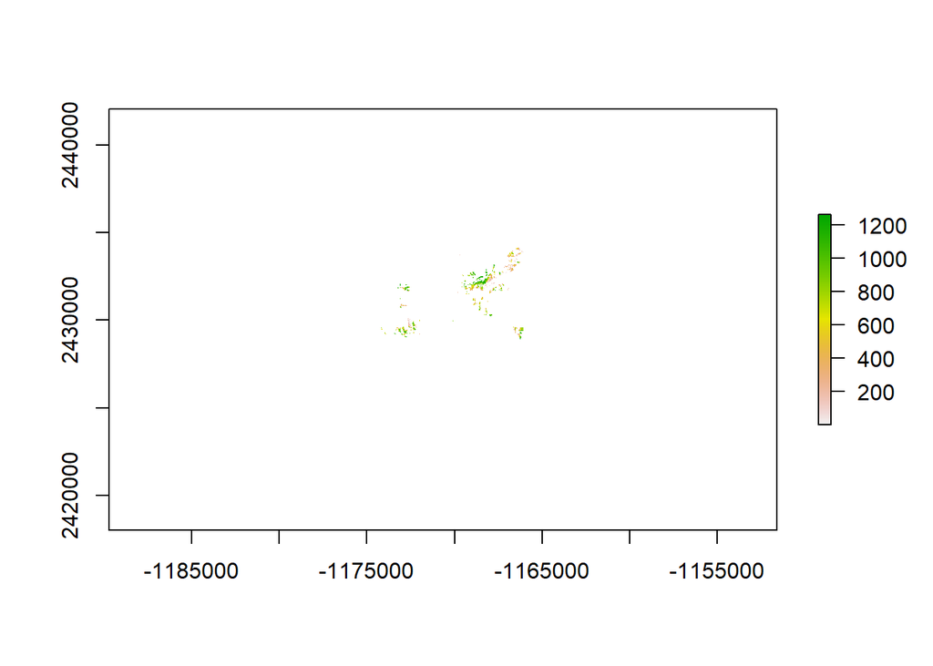

```r
### sev young is everything inside of huck + adams hill perimeter that burned as moderate - high severity in
# first fire
# glade and wilcox omitted from young forest due to small reburn area (glade) and different forest types (wilcox)

# read in and mask fire severity based on huck x adams hill fire severity
huck.mtbs = raster("data/MTBS/Lake_Creek/wy4415711051919880711/wy4415711051919880711_19860818_19890802_rdnbr.tif")
huck.mask = reclassify(huck.mtbs, matrix(c(-Inf,675,NA,675,2000,1,2000,Inf,NA)))
huck.cmask = crop(huck.mask,sev.con)

# sev young is everything inside of lake perimeter that burned as stand-replacing fire
sev.young = mask(sev.con, huck.cmask)

# only high fire spread days, to keep fire weather similar
sevHi.young = mask(sev.young, growthHi)
plot(sevHi.young)
```

```r
# also read in glade and wilcox perimeters, use these to determine how many of the
# moderate v. severe fire weather randomly sampled polygons represented young forest for q3
glade.mtbs = raster("data/MTBS/Glade/wy4409911072120000815/wy4409911072120000815_20000723_20010726_dnbr6.tif")
glade.mask = reclassify(glade.mtbs, matrix(c(-Inf,2.9,NA,2.9,4.9,1,4.9,Inf,NA)))

wilcox.mtbs = raster("data/MTBS/Wilcox/wy4397811071720000815_20000723_20010726_dnbr6.tif")
wilcox.mask = reclassify(wilcox.mtbs, matrix(c(-Inf,2.9,NA,2.9,4.9,1,4.9,Inf,NA)))
```

## 5. Take random sample for Q1 and Q2

I first created a function to randomly sample grid cells separated by a minimum distance. Then, for Q1, I compared fuels and burn severity in young versus mature forest that burned under similar fire weather using a random sample of 30 cells in each category separated by a minimum of 500 m. For this question, young forest only included ~30-year-old forest that first burned in 1987 or 1988. For Q2, I examined how well fuels predicted burn severity under moderate versus extreme fire weather using a random sample of 50 cells in each category separated by a minimum of 500 m. This sample was taken from throughout the entire perimeter, so it included mature forest as well as reburns of forest recovering from previous fire in 1987, 1988, and 2000.

This chunk takes a while to run and stores large files in memory so is not evaluated when knitted. Outputs are saved from previous run and reloaded in following chunk.

```r
### full sampling pipeline as function

rand_samp = function(r.sub, dist.in, npts) {

  # switch to polygons
  sub.poly = rasterToPolygons(r.sub)
  sub.utm = spTransform(sub.poly, CRSobj=crs(dem.in))

  # create distance matrix
  dmat = spDists(sub.utm)

  # set min distance between points
  min.dist = dist.in
  dmat[dmat <= min.dist] = NA

  # create loop to pull one sample at a time
  # exclude anything within min dist
  # and continue to max sample

  # full sample pool starts with all points
  pool = as.numeric(rownames(sub.utm@data))

  # output data frame
  randpts = data.frame()

  for(i in 1:npts) {

    # break if only 1 point left
    # if set this to length = 0 only, problems with output
    if(length(pool) <= 1) {
      break
    }

    # take 1 random point
    rand1 = sample(pool, 1, replace=FALSE)

    # update pool to exclude everything within min dist
    dmat.dist = dmat[rand1,]
    dmat.pts = which(is.na(dmat.dist))
    pool = pool[!pool %in% dmat.pts]

    # add to df
    randpts = rbind(randpts, data.frame(ID=rand1))
  }

  # get polys using ids
  sub.out = sub.utm[c(randpts$ID),]

  return(sub.out)

}


# sample these rasters
# use seeds to ensure consistency with code reruns
# sample(1:1000,1)

### q2 samples
set.seed(552)
sampleYoung = rand_samp(sevHi.young, dist.in = 500, npts=30) %>%
  st_as_sf()

set.seed(520)
sampleOld = rand_samp(sevHi.old, dist.in = 500, npts = 30) %>%
  st_as_sf()

### q3 samples
set.seed(866)
sampleMod = rand_samp(growthMod, dist.in = 500, npts=50) %>%
  st_as_sf()

set.seed(887)
sampleHi = rand_samp(growthHi, dist.in = 500, npts=50) %>%
  st_as_sf()

# not evaluated when knit
plot(sampleYoung)
plot(sampleOld)
plot(sampleMod)
plot(sampleHi)

summary(sampleYoung)
summary(sampleOld)
summary(sampleMod)
summary(sampleHi)
```

## 6. Match up random samples with fire history, burn date

For Q2, I used fire progression maps to match up burn date and fire history (i.e., whether that pixel had previously burned at either moderate or high severity in 1987, 1988, or 2000) with each cell in our random samples.

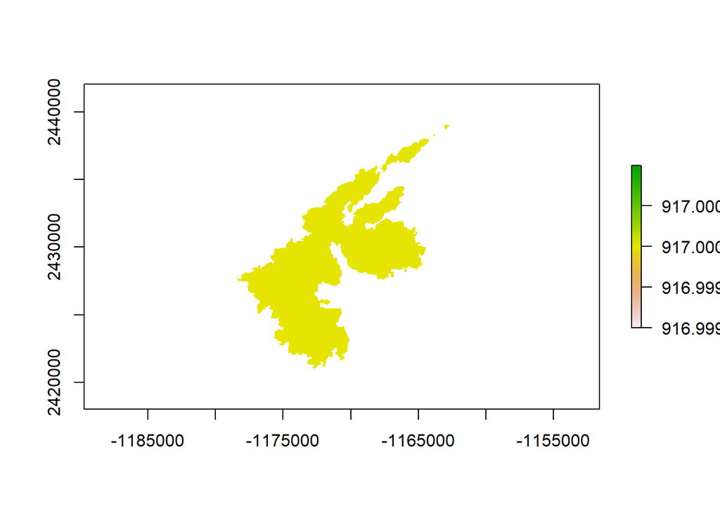

```r
### load random samples, filter to align with previous chunk
sampleYoung = st_read("processed_data/Berry_Fire_sample_polys/berry_fire_age_sample.shp") %>%
  filter(age=="young") %>%
  dplyr::select(rdnbr, geometry) %>%
  rename(wy4402111078620160725_20160719_20170722_rdnbr = rdnbr)
sampleOld = st_read("processed_data/Berry_Fire_sample_polys/berry_fire_age_sample.shp") %>%
  filter(age=="old") %>%
  dplyr::select(rdnbr, geometry) %>%
  rename(wy4402111078620160725_20160719_20170722_rdnbr = rdnbr)
sampleMod = st_read("processed_data/Berry_Fire_sample_polys/berry_fire_wx_sample.shp") %>%
  filter(weather=="moderate") %>%
  dplyr::select(rdnbr, geometry) %>%
  rename(wy4402111078620160725_20160719_20170722_rdnbr = rdnbr)
sampleHi = st_read("processed_data/Berry_Fire_sample_polys/berry_fire_wx_sample.shp") %>%
  filter(weather=="extreme") %>%
  dplyr::select(rdnbr, geometry) %>%
  rename(layer = rdnbr)

### create master spread date raster

# start with final fire perimeter
perim.rast = perim.in %>%
  st_as_sf() %>%
  # transform to crs of severity raster
  st_transform(crs=crs(sev.con)) %>%
  # rasterize to severity raster, use value to indicate burn date
  fasterize(sev.con) * 917

plot(perim.rast)
```

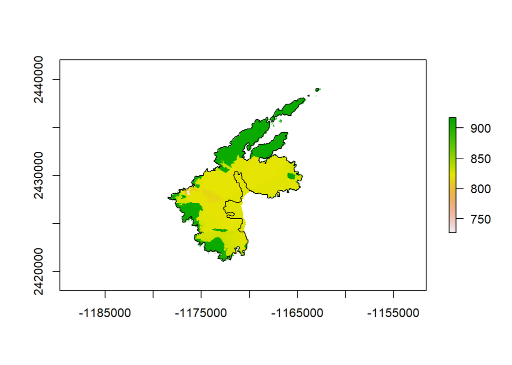

```r
r.master = perim.rast

# function to add a new raster on top based on fire progression and add to r.master
fire_prog = function(sf.in, date.in) {
  newPerim = st_read(sf.in) %>%
    st_transform(crs=crs(sev.con)) %>%
    fasterize(sev.con) * date.in

  r.master = merge(newPerim,r.master)

  return(r.master)

}

# iteratively add growth perimeter for each date
r.master = fire_prog("data/GeoMAC/2016_fire_data/Wyoming/Berry/wy_berry_20160917_0108_dd83.shp", 916)
r.master = fire_prog("data/GeoMAC/2016_fire_data/Wyoming/Berry/wy_berry_20160915_1743_dd83.shp", 915)
r.master = fire_prog("data/GeoMAC/2016_fire_data/Wyoming/Berry/wy_berry_20160912_0058_dd83.shp", 911)
r.master = fire_prog("data/GeoMAC/2016_fire_data/Wyoming/Berry/wy_berry_20160910_2256_dd83.shp", 910)
r.master = fire_prog("data/GeoMAC/2016_fire_data/Wyoming/Berry/wy_berry_20160909_2210_dd83.shp", 909)
r.master = fire_prog("data/GeoMAC/2016_fire_data/Wyoming/Berry/wy_berry_20160905_1301_dd83.shp", 905)
r.master = fire_prog("data/GeoMAC/2016_fire_data/Wyoming/Berry/wy_berry_20160902_2059_dd83.shp", 902)
r.master = fire_prog("data/GeoMAC/2016_fire_data/Wyoming/Berry/wy_berry_20160902_0152_dd83.shp", 901)
r.master = fire_prog("data/GeoMAC/2016_fire_data/Wyoming/Berry/wy_berry_20160901_0000_dd83.shp", 831)
r.master = fire_prog("data/GeoMAC/2016_fire_data/Wyoming/Berry/wy_berry_20160830_2339_dd83.shp", 830)
r.master = fire_prog("data/GeoMAC/2016_fire_data/Wyoming/Berry/wy_berry_20160829_2201_dd83.shp", 829)
r.master = fire_prog("data/GeoMAC/2016_fire_data/Wyoming/Berry/wy_berry_20160829_0100_dd83.shp", 828)
r.master = fire_prog("data/GeoMAC/2016_fire_data/Wyoming/Berry/wy_berry_20160827_2043_dd83.shp", 827)
r.master = fire_prog("data/GeoMAC/2016_fire_data/Wyoming/Berry/wy_berry_20160827_0117_dd83.shp", 826)
r.master = fire_prog("data/GeoMAC/2016_fire_data/Wyoming/Berry/wy_berry_20160824_2112_dd83.shp", 824)
r.master = fire_prog("data/GeoMAC/2016_fire_data/Wyoming/Berry/wy_berry_20160822_2009_dd83.shp", 822)
r.master = fire_prog("data/GeoMAC/2016_fire_data/Wyoming/Berry/wy_berry_20160822_0221_dd83.shp", 821)
r.master = fire_prog("data/GeoMAC/2016_fire_data/Wyoming/Berry/wy_berry_20160818_0205_dd83.shp", 817)
r.master = fire_prog("data/GeoMAC/2016_fire_data/Wyoming/Berry/wy_berry_20160816_0217_dd83.shp", 815)
r.master = fire_prog("data/GeoMAC/2016_fire_data/Wyoming/Berry/wy_berry_20160810_0000_dd83.shp", 809)
r.master = fire_prog("data/GeoMAC/2016_fire_data/Wyoming/Berry/wy_berry_20160807_0000_dd83.shp", 806)
r.master = fire_prog("data/GeoMAC/2016_fire_data/Wyoming/Berry/wy_berry_20160805_1500_dd83.shp", 805)
r.master = fire_prog("data/GeoMAC/2016_fire_data/Wyoming/Berry/wy_berry_20160731_0000_dd83.shp", 730)
r.master = fire_prog("data/GeoMAC/2016_fire_data/Wyoming/Berry/wy_berry_20160727_2100_dd83.shp", 727)

plot(r.master)
plot(perim.in, add=TRUE)
```

```r
# match up date with high spread days
sampleHi.date = sampleHi %>%
  st_transform(st_crs(r.master)) %>%
  mutate(date = as.integer(extract(r.master,.))) %>%
  mutate(date = factor(date),
         weather = "extreme") %>%
  rename(rdnbr=layer) %>%
  st_transform(st_crs(dem.in))

summary(sampleHi.date)

# match up date with low spread days
sampleMod.date = sampleMod %>%
  st_transform(st_crs(r.master)) %>%
  mutate(date = as.integer(extract(r.master,.))) %>%
  mutate(date = factor(date),
         weather = "moderate") %>%
  rename(rdnbr=wy4402111078620160725_20160719_20170722_rdnbr) %>%
  st_transform(st_crs(dem.in))

summary(sampleMod.date)
```

## 6. Add topographic information and export

I also matched up topographic information and exported final randomly selected cells.

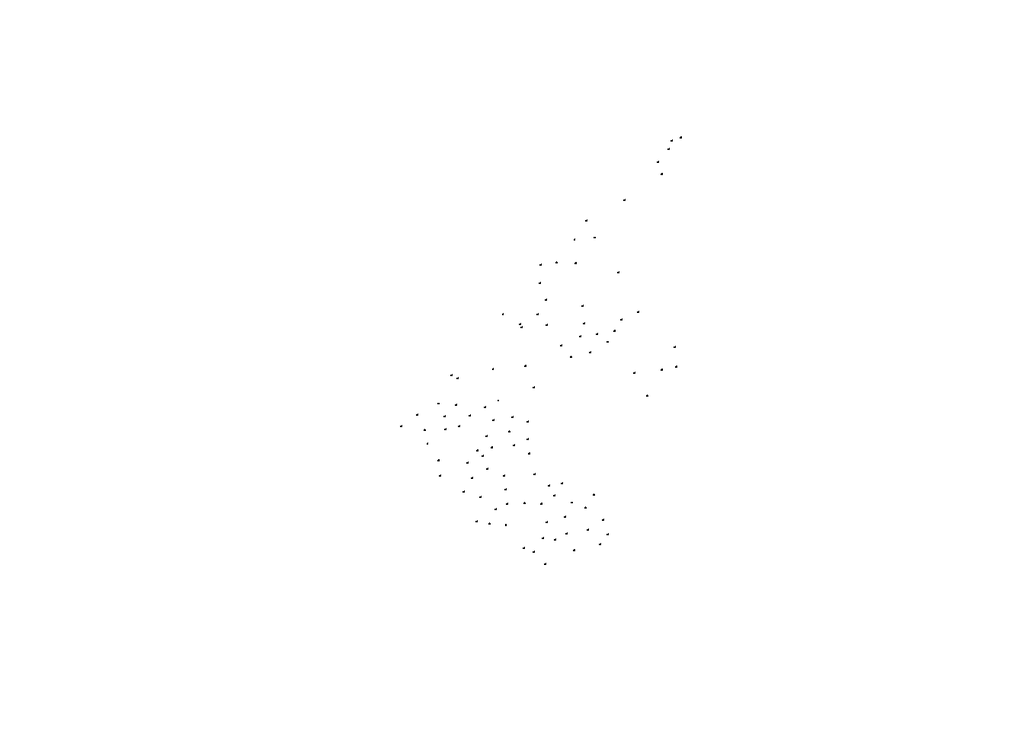

```r
# combine old, young dataset
sampleOld.class = sampleOld %>%
  mutate(age = "old") %>%
  rename(rdnbr = wy4402111078620160725_20160719_20170722_rdnbr)

sample.age = sampleYoung %>%
  mutate(age = "young") %>%
  rename(rdnbr = wy4402111078620160725_20160719_20170722_rdnbr) %>%
  rbind(sampleOld.class)

# combine mod, hi fire wx datasets
sample.wx = sampleMod.date %>%
  rbind(sampleHi.date)

plot(st_geometry(sample.wx))
```

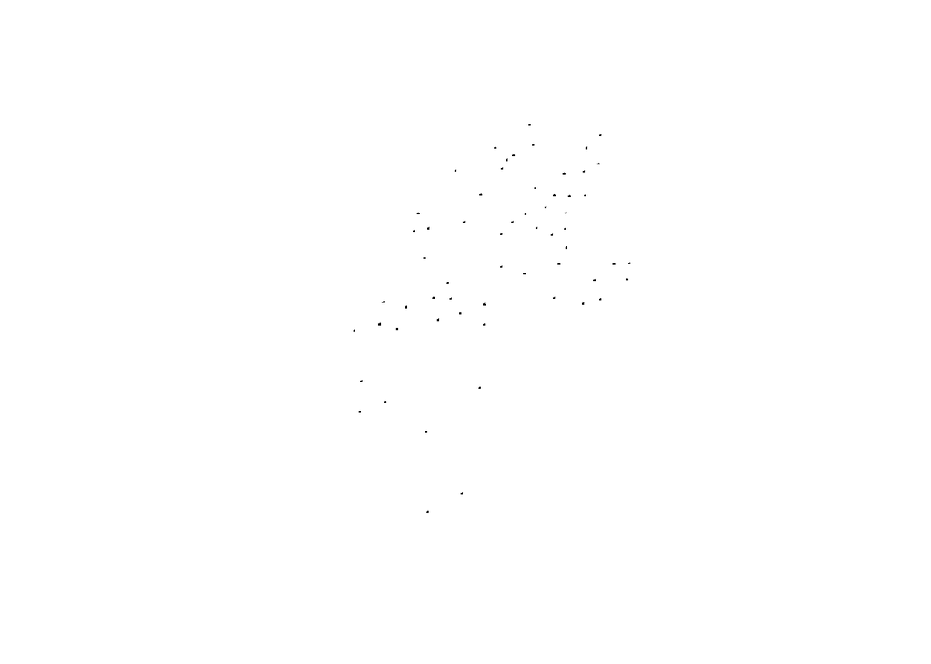

```r
plot(st_geometry(sample.age))
```

```r
### add topographic information
dem.slope = terrain(dem.in, opt="slope", unit="degrees")
dem.aspect = terrain(dem.in, opt="aspect", unit="degrees")

sample.ageout = sample.age %>%
  mutate(elev_m = extract(dem.in,.,fun=mean,weights=TRUE),
         slope_deg = extract(dem.slope, .,fun=mean,weights=TRUE),
         aspect_deg = extract(dem.aspect, .,fun=mean,weights=TRUE))  %>%
  mutate(sample_id = row_number())

# also add previous fire information to wx sample
sample.wxout = sample.wx %>%
  st_transform(crs = crs(huck.mask)) %>%
  # previously burned as mod to severe fire
  mutate(adams_huck = extract(huck.mask,.,fun=mean),
         glade = extract(glade.mask,.,fun=mean),
         wilcox = extract(wilcox.mask,.,fun=mean),
         prev_fire = ifelse(adams_huck == 1 & !is.na(adams_huck), "adams_huck",
                            ifelse(glade == 1 & !is.na(glade), "glade",
                                   ifelse(wilcox ==1 & !is.na(wilcox), "wilcox","none")))) %>%
  mutate(prev_fire = as.factor(prev_fire)) %>%
  dplyr::select(-c(adams_huck:wilcox)) %>%
  # transform back
  st_transform(crs = crs(dem.in)) %>%
  # add topographic information
  mutate(elev_m = extract(dem.in,.,fun=mean,weights=TRUE),
         slope_deg = extract(dem.slope, .,fun=mean,weights=TRUE),
         aspect_deg = extract(dem.aspect, .,fun=mean,weights=TRUE))  %>%
  mutate(sample_id = row_number())

# data summaries
sample.ageout %>%
  filter(age=="young") %>%
  summary()
```

```
##      rdnbr            age                     geometry
##  Min.   :  14.0   Length:30          POLYGON      :30
##  1st Qu.: 395.0   Class :character   epsg:NA      : 0
##  Median : 612.5   Mode  :character   +proj=utm ...: 0
##  Mean   : 599.4
##  3rd Qu.: 788.5
##  Max.   :1035.0
##       elev_m.V1         slope_deg.V1       aspect_deg.V1
##  Min.   :2102.0584   Min.   : 2.90981   Min.   : 13.25321
##  1st Qu.:2156.6110   1st Qu.: 7.95007   1st Qu.: 54.58812
##  Median :2248.7342   Median :10.87867   Median :178.20765
##  Mean   :2254.9421   Mean   :13.00439   Mean   :168.92311
##  3rd Qu.:2315.0010   3rd Qu.:15.77063   3rd Qu.:274.97063
##  Max.   :2650.0291   Max.   :35.03184   Max.   :310.93275
##    sample_id
##  Min.   : 1.00
##  1st Qu.: 8.25
##  Median :15.50
##  Mean   :15.50
##  3rd Qu.:22.75
##  Max.   :30.00
```

```r
sample.ageout %>%
  filter(age=="old") %>%
  summary()
```

```
##      rdnbr            age                     geometry
##  Min.   :  15.0   Length:30          POLYGON      :30
##  1st Qu.: 327.5   Class :character   epsg:NA      : 0
##  Median : 675.5   Mode  :character   +proj=utm ...: 0
##  Mean   : 695.7
##  3rd Qu.: 989.2
##  Max.   :1310.0
##       elev_m.V1         slope_deg.V1       aspect_deg.V1
##  Min.   :2068.2427   Min.   : 1.509289   Min.   :  8.8078
##  1st Qu.:2122.3375   1st Qu.: 4.570182   1st Qu.: 65.8001
##  Median :2225.6036   Median : 8.139314   Median :113.1574
##  Mean   :2228.0371   Mean   :10.500954   Mean   :159.8866
##  3rd Qu.:2320.5834   3rd Qu.:16.162889   3rd Qu.:257.2839
##  Max.   :2440.1377   Max.   :28.492977   Max.   :333.5271
##    sample_id
##  Min.   :31.00
##  1st Qu.:38.25
##  Median :45.50
##  Mean   :45.50
##  3rd Qu.:52.75
##  Max.   :60.00
```

```r
sample.wxout %>%
  filter(weather=="moderate") %>%
  summary()
```

```
##      rdnbr             date      weather               prev_fire
##  Min.   :   0.0   821    :10   Length:50          adams_huck: 0
##  1st Qu.: 170.2   917    : 7   Class :character   glade     : 0
##  Median : 439.5   830    : 6   Mode  :character   none      :42
##  Mean   : 493.0   826    : 5                      wilcox    : 8
##  3rd Qu.: 721.2   815    : 4
##  Max.   :1301.0   829    : 4
##                   (Other):14
##           geometry       elev_m.V1         slope_deg.V1
##  POLYGON      :50   Min.   :2076.4453   Min.   : 3.60731
##  epsg:26912   : 0   1st Qu.:2219.7424   1st Qu.:10.10393
##  +proj=utm ...: 0   Median :2335.3196   Median :16.37629
##                     Mean   :2346.8734   Mean   :16.42619
##                     3rd Qu.:2492.9649   3rd Qu.:19.79475
##                     Max.   :2686.3987   Max.   :37.51277
##
##    aspect_deg.V1      sample_id
##  Min.   : 21.5324   Min.   : 1.00
##  1st Qu.: 69.5542   1st Qu.:13.25
##  Median :121.0145   Median :25.50
##  Mean   :144.6700   Mean   :25.50
##  3rd Qu.:226.4042   3rd Qu.:37.75
##  Max.   :348.1247   Max.   :50.00
##
```

```r
sample.wxout %>%
  filter(weather=="extreme") %>%
  summary()
```

```
##      rdnbr             date      weather               prev_fire
##  Min.   :   8.0   911    :24   Length:50          adams_huck: 2
##  1st Qu.: 311.5   822    :16   Class :character   glade     : 1
##  Median : 716.5   824    :10   Mode  :character   none      :45
##  Mean   : 705.2   809    : 0                      wilcox    : 2
##  3rd Qu.:1118.0   815    : 0
##  Max.   :1296.0   817    : 0
##                   (Other): 0
##           geometry       elev_m.V1         slope_deg.V1
##  POLYGON      :50   Min.   :2068.1302   Min.   : 0.11136
##  epsg:26912   : 0   1st Qu.:2108.4841   1st Qu.: 5.32422
##  +proj=utm ...: 0   Median :2230.5993   Median :11.36534
##                     Mean   :2243.5251   Mean   :14.05095
##                     3rd Qu.:2317.1595   3rd Qu.:19.66251
##                     Max.   :2617.9132   Max.   :40.72761
##
##    aspect_deg.V1      sample_id
##  Min.   :  5.8084   Min.   : 51.00
##  1st Qu.: 70.1989   1st Qu.: 63.25
##  Median :146.6017   Median : 75.50
##  Mean   :164.3405   Mean   : 75.50
##  3rd Qu.:265.9190   3rd Qu.: 87.75
##  Max.   :348.8377   Max.   :100.00
##
```

```r
# ### write out shapefiles
# st_write(sample.ageout,dsn="processed_data/Berry_Fire_sample_polys/berry_fire_age_sample.shp")
# st_write(sample.wxout,dsn="processed_data/Berry_Fire_sample_polys/berry_fire_wx_sample.shp")
```

## 8. Calculate summary Berry Fire stats

I calculated summary statistics for the Berry Fire, including total area burned, area reburned, area burned on moderate versus extreme fire weather days, and weather conditions on moderate versus extreme fire weather days.

```r
### area calculations
# total area
head(perim.in) # 20122 acres
```

```
##   Id        Area   Perimeter       Acres               Fire_ID Fire_Name
## 0  0 81431698.66 107079.7969 20122.21247 WY4402111078620160725     BERRY
## 1  0  2602955.96  11214.6846   643.20447 WY4402111078620160725     BERRY
## 2  0    59881.65   1007.7576    14.79708 WY4402111078620160725     BERRY
## 3  0    13082.64    443.1466     3.23279 WY4402111078620160725     BERRY
##   Year StartMonth StartDay Confidence Comment Mapping_ID
## 0 2016          7       25       High    <NA>   10004889
## 1 2016          7       25       High    <NA>   10004889
## 2 2016          7       25       High    <NA>   10004889
## 3 2016          7       25       High    <NA>   10004889
```

```r
# fire burned into October
20122/2.471 # 8143 ha
```

```
## [1] 8143.262
```

```r
# use fire spread perimeters to derive area burned on high spread days
area_burned_911 = gIntersection(perim.in, post911.aea) %>%
  gDifference(pre911.aea) %>%
  st_as_sf() %>%
  st_area

area_burned_822_824 = gIntersection(perim.in, post824.aea) %>%
  gDifference(pre822.aea) %>%
  st_as_sf() %>%
  st_area

(area_burned_911 + area_burned_822_824) / 10000 # 6077
```

```
## 6077.333 [m^2]
```

```r
8143-6077
```

```
## [1] 2066
```

```r
# vet by comparison with spread raster, not exact but should be ballpark
spread.rast = mask(r.master, perim.in)
data.frame(spread_date = getValues(spread.rast)) %>%
  filter(spread_date %in% c("822","824","911")) %>%
  tally() * 30 * 30 / 10000 # 6053
```

```
##        n
## 1 6053.4
```

```r
# next use fire spread and previous fire perimeters to derive
# area of young forest burned
glade_reburn = gIntersection(perim.in, glade.aea) %>%
  st_as_sf() %>%
  st_area / 10000

wilcox_reburn = gIntersection(perim.in, wilcox.aea) %>%
  st_as_sf() %>%
  st_area / 10000

huckadams_reburn = gIntersection(perim.in, lake.aea) %>%
  st_as_sf() %>%
  st_area / 10000

(glade_reburn + wilcox_reburn + huckadams_reburn) / 8143
```

```
## 0.4251138 [m^2]
```

```r
# compare to sev.old for gut check, should be < 57 % of fire perimeter
old.df = data.frame(old_rdnbr = getValues(sev.old))
old.df %>%
  filter(!is.na(old_rdnbr)) %>%
  tally() * 30 * 30 / 10000 / 8143 # 47%
```

```
##           n
## 1 0.4784711
```

```r
### fire weather calculations
# read in raws data
raws = read.table("data/GRTE_RAWS/GRTE_RAWS.txt", header=FALSE, skip=6, nrows=53)

names(raws) = c("date","year","day","id","solar_rad_kWhm2","wind_speed_avg_mSec","wind_dir_deg","wind_speed_gust_mSec",
                "air_temp_avg_C","air_temp_max_C","air_temp_min_C","rh_avg_pct","rh_max_pct","rh_min_ct","prec_mm")

head(raws)
```

```
##         date year day id solar_rad_kWhm2 wind_speed_avg_mSec wind_dir_deg
## 1 07/25/2016 2016 207  1           8.195                1.88          259
## 2 07/26/2016 2016 208  2           7.808                2.63          329
## 3 07/27/2016 2016 209  3           7.871                2.25          289
## 4 07/28/2016 2016 210  4           8.017                2.38          320
## 5 07/29/2016 2016 211  5           7.533                2.12          282
## 6 07/30/2016 2016 212  6           6.490                3.22          221
##   wind_speed_gust_mSec air_temp_avg_C air_temp_max_C air_temp_min_C
## 1                 9.84           18.2           30.6            3.9
## 2                13.86           19.8           30.0            5.6
## 3                 8.49           19.3           29.4            6.7
## 4                 9.39           20.3           29.4           12.2
## 5                 8.05           19.2           30.0            8.3
## 6                12.07           19.2           30.0            8.3
##   rh_avg_pct rh_max_pct rh_min_ct prec_mm
## 1         35         77        10       0
## 2         32         75        10       0
## 3         34         69        12       0
## 4         35         61         9       0
## 5         41         82        13       0
## 6         43         71        17       0
```

```r
# extreme weather days
raws %>%
  mutate(wind_speed_gust_kmHr = wind_speed_gust_mSec * 60*60 * 1/1000) %>%
  filter(date %in% c("08/22/2016","08/23/2016","08/24/2016","09/11/2016")) %>%
  summary()
```

```
##          date        year           day              id
##  08/22/2016:1   Min.   :2016   Min.   :235.0   Min.   :29.00
##  08/23/2016:1   1st Qu.:2016   1st Qu.:235.8   1st Qu.:29.75
##  08/24/2016:1   Median :2016   Median :236.5   Median :30.50
##  09/11/2016:1   Mean   :2016   Mean   :240.8   Mean   :34.75
##  07/25/2016:0   3rd Qu.:2016   3rd Qu.:241.5   3rd Qu.:35.50
##  07/26/2016:0   Max.   :2016   Max.   :255.0   Max.   :49.00
##  (Other)   :0
##  solar_rad_kWhm2 wind_speed_avg_mSec  wind_dir_deg   wind_speed_gust_mSec
##  Min.   :5.870   Min.   :2.420       Min.   : 18.0   Min.   :12.07
##  1st Qu.:5.921   1st Qu.:2.922       1st Qu.:173.2   1st Qu.:13.07
##  Median :5.992   Median :3.205       Median :228.5   Median :14.30
##  Mean   :6.115   Mean   :3.297       Mean   :177.2   Mean   :15.87
##  3rd Qu.:6.186   3rd Qu.:3.580       3rd Qu.:232.5   3rd Qu.:17.10
##  Max.   :6.606   Max.   :4.360       Max.   :234.0   Max.   :22.80
##
##  air_temp_avg_C  air_temp_max_C  air_temp_min_C    rh_avg_pct
##  Min.   :11.70   Min.   :21.70   Min.   :-2.20   Min.   :23.00
##  1st Qu.:13.28   1st Qu.:22.52   1st Qu.:-0.10   1st Qu.:26.00
##  Median :13.85   Median :23.90   Median : 1.95   Median :27.00
##  Mean   :13.95   Mean   :24.05   Mean   : 1.25   Mean   :28.25
##  3rd Qu.:14.53   3rd Qu.:25.43   3rd Qu.: 3.30   3rd Qu.:29.25
##  Max.   :16.40   Max.   :26.70   Max.   : 3.30   Max.   :36.00
##
##    rh_max_pct      rh_min_ct        prec_mm  wind_speed_gust_kmHr
##  Min.   :45.00   Min.   : 7.00   Min.   :0   Min.   :43.45
##  1st Qu.:55.50   1st Qu.: 9.25   1st Qu.:0   1st Qu.:47.07
##  Median :62.00   Median :10.50   Median :0   Median :51.50
##  Mean   :58.75   Mean   :10.00   Mean   :0   Mean   :57.13
##  3rd Qu.:65.25   3rd Qu.:11.25   3rd Qu.:0   3rd Qu.:61.56
##  Max.   :66.00   Max.   :12.00   Max.   :0   Max.   :82.08
##
```

```r
# moderate weather days
raws %>%
  mutate(wind_speed_gust_kmHr = wind_speed_gust_mSec * 60*60 * 1/1000) %>%
  filter(!date %in% c("08/22/2016","08/23/2016","08/24/2016","09/11/2016")) %>%
  summary()
```

```
##          date         year           day              id
##  07/25/2016: 1   Min.   :2016   Min.   :207.0   Min.   : 1.00
##  07/26/2016: 1   1st Qu.:2016   1st Qu.:219.0   1st Qu.:13.00
##  07/27/2016: 1   Median :2016   Median :231.0   Median :25.00
##  07/28/2016: 1   Mean   :2016   Mean   :232.4   Mean   :26.37
##  07/29/2016: 1   3rd Qu.:2016   3rd Qu.:246.0   3rd Qu.:40.00
##  07/30/2016: 1   Max.   :2016   Max.   :259.0   Max.   :53.00
##  (Other)   :43
##  solar_rad_kWhm2 wind_speed_avg_mSec  wind_dir_deg   wind_speed_gust_mSec
##  Min.   :2.759   Min.   :1.280       Min.   :  3.0   Min.   : 6.26
##  1st Qu.:4.875   1st Qu.:2.050       1st Qu.:226.0   1st Qu.: 9.39
##  Median :6.189   Median :2.380       Median :249.0   Median :11.18
##  Mean   :5.951   Mean   :2.517       Mean   :237.2   Mean   :11.51
##  3rd Qu.:7.021   3rd Qu.:2.940       3rd Qu.:272.0   3rd Qu.:13.86
##  Max.   :8.195   Max.   :4.620       Max.   :334.0   Max.   :16.99
##
##  air_temp_avg_C  air_temp_max_C  air_temp_min_C     rh_avg_pct
##  Min.   : 7.80   Min.   :12.80   Min.   :-2.800   Min.   :26.00
##  1st Qu.:12.60   1st Qu.:21.70   1st Qu.: 3.300   1st Qu.:35.00
##  Median :15.70   Median :26.10   Median : 5.000   Median :39.00
##  Mean   :15.06   Mean   :24.76   Mean   : 4.773   Mean   :43.88
##  3rd Qu.:18.10   3rd Qu.:29.40   3rd Qu.: 6.700   3rd Qu.:49.00
##  Max.   :20.30   Max.   :30.60   Max.   :12.200   Max.   :86.00
##
##    rh_max_pct      rh_min_ct        prec_mm       wind_speed_gust_kmHr
##  Min.   :55.00   Min.   : 4.00   Min.   :0.0000   Min.   :22.54
##  1st Qu.:66.00   1st Qu.:12.00   1st Qu.:0.0000   1st Qu.:33.80
##  Median :75.00   Median :14.00   Median :0.0000   Median :40.25
##  Mean   :76.49   Mean   :17.84   Mean   :0.4457   Mean   :41.42
##  3rd Qu.:89.00   3rd Qu.:20.00   3rd Qu.:0.0000   3rd Qu.:49.90
##  Max.   :99.00   Max.   :49.00   Max.   :7.6200   Max.   :61.16
##
```